# Exploring the BRFSS data

## Setup

### Load packages

```r
library(ggplot2)
library(dplyr)
library(reshape)
library(knitr)
```

### Load data

Loading data:

```r
load("brfss2013.RData")
```

## Part 1: Data

The BRFSS is an observation project. Therefore, it is not possible to find out causality as it is not a controlled experiment and there is no random assignment.

All 50 states, the District of Columbia, Puerto Rico, and Guam collect data annually and American Samoa, Federated States of Micronesia, and Palau collect survey data over a limited point- in-time (usually one to three months). Therefore, we have a *representative sample* including all US states and territories.

The BRFSS counducts telephone interviews using *random* selection. The BRFSS also conducts cellphone interviews to include residences that do not have a landline number.

There is a **representative** sample from across the country and covering people with both landlines and cellphones. The samples are randomly selected by the researchers in each *“state”*. Therefore, there is random sampling. We can safely conclude that the study is **generalizable**.

The only reservations are:

- Citizens without cellphones and landlines may not be covered.
- Homeless people may not be covered or hermits and monks living in the forest.

## Part 2: Research questions

**Research quesion 1:**

Are city dwellers healthier than their suburban and rural counterparts?

This question interests me because I assume that being outside the frantic hustle and bustle of city life outside work hours is conducive to mental and physical health. Although, it isn’t the only factor. We may be able to draw correlations, we cannot establish causality as it is not a controlled experiment.

**Research quesion 2:** Is there a difference in proportion of current smokers who are male graduates, female graduate, male non-graduates and female non-graduate?

My initial assumption is that the group with the largest proportion of smokers would be male non-graduates followed by male graduates. An understanding of which demographic is likely to be a current smoker would enable us to create specifically tailored health outreach programs.

**Research quesion 3:** Is there any relation between general health and race,sex?

It would be interesting to understand how is the general health of people of different races, sex This might inform deeper experimental studies to understand what are the causes for the good and bad overall health for people belonging to a cerain race, sex

## Part 3: Exploratory data analysis

**Research quesion 1:**

For this question, we make use of the following variables:

- *mscode*: Metropolitan Status Code.
- Calculated variable *_rfhlth*: Adults With Good Or Better Health.

The metropolitan status code has 5 levels

1. In the center city of an MSA
- Outside the center city of an MSA but inside the county containing the center city
- Inside a suburban county of the MSA
- In an MSA that has no center city
- Not in an MSA

We classify level 1 and 2 as city dweller and the others as not a city dweller. We, therefore create a new variable called *citydweller*.

Let us first explore *mscode* a bit.

```r
brfss2013%>% group_by(mscode) %>%
  summarise(total=n())
```

```
## # A tibble: 6 x 2
##   mscode                                                             total
##   <fct>                                                              <int>
## 1 In the center city of an MSA                                      110207
## 2 Outside the center city of an MSA but inside the county containi…  63114
## 3 Inside a suburban county of the MSA                                52513
## 4 In an MSA that has no center city                                   1819
## 5 Not in an MSA                                                     127479
## 6 <NA>                                                              136643
```

Create a new variable citydweller

```r
mscode_levels<-levels(brfss2013$mscode)
city1<-mscode_levels[1]
city2<-mscode_levels[2]
brfss2013<-brfss2013%>%
  mutate(citydweller = ifelse(mscode==city1|mscode==city2,"City dweller","Not a city dweller") )
#Verification
brfss2013%>% filter(mscode==city1|mscode==city2)%>%
  group_by(citydweller)%>%
  summarise(total=n())
```

```
## # A tibble: 1 x 2
##   citydweller   total
##   <chr>         <int>
## 1 City dweller 173321
```

First, we find out some summary statistics for city dweller vs not a city dweller.

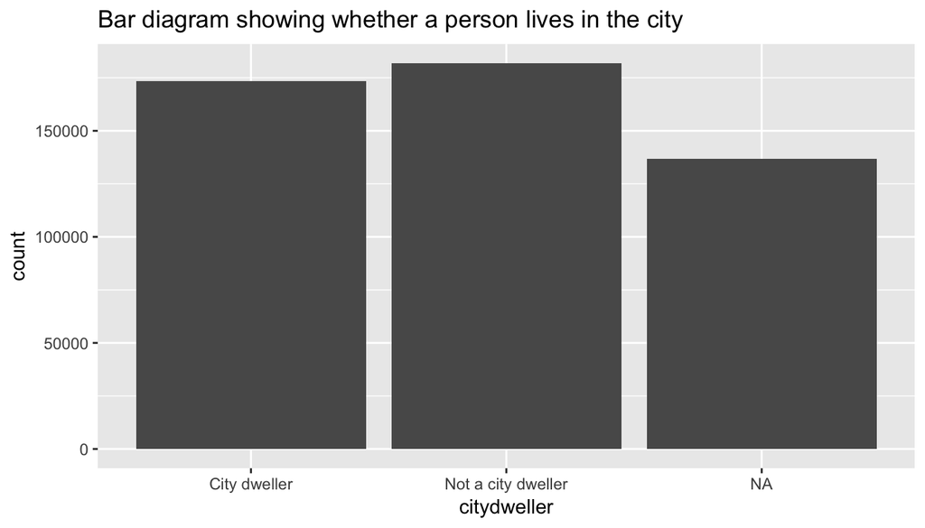

```r
ggplot(data=brfss2013,aes(x=citydweller))+geom_bar()+ ggtitle("Bar diagram showing whether a person lives in the city")
```

```r
brfss2013[!is.na(brfss2013$citydweller),]%>%group_by(citydweller)%>%
  summarise(total=n())
```

```
## # A tibble: 2 x 2
##   citydweller         total
##   <chr>               <int>
## 1 City dweller       173321
## 2 Not a city dweller 181811
```

For our summary statistics, we filtered out NA. There is an even split between city dwellers and not a city dwellers.

Now, we construct a bar plot concerning the health of a city dweller.

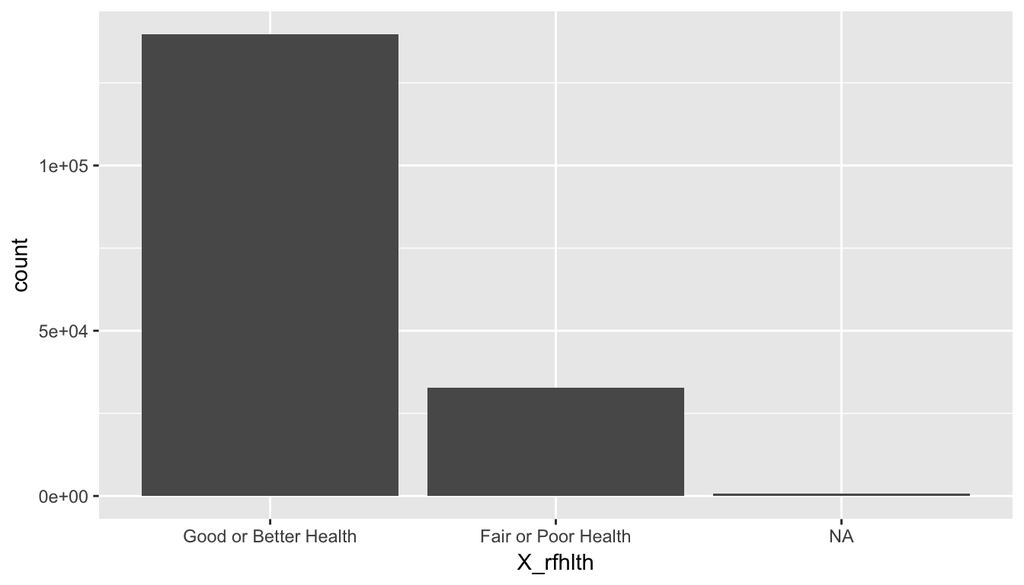

```r
city_dweller_data<- brfss2013%>%
  filter(citydweller=="City dweller")
ggplot(city_dweller_data,aes(x=X_rfhlth)) + geom_bar()
```

```r
city_dweller_summary_total<-city_dweller_data[!is.na(city_dweller_data$X_rfhlth),] %>% group_by(X_rfhlth) %>%
  summarise(total= n())
city_dweller_summary_total
```

```
## # A tibble: 2 x 2
##   X_rfhlth               total
##   <fct>                  <int>
## 1 Good or Better Health 139711
## 2 Fair or Poor Health    32814
```

```r
total_city_dweller= sum(!is.na(city_dweller_data$X_rfhlth))
city_dweller_data[!is.na(city_dweller_data$X_rfhlth),] %>% group_by(X_rfhlth) %>%
  summarise(proportion= n()/total_city_dweller)
```

```
## # A tibble: 2 x 2
##   X_rfhlth              proportion
##   <fct>                      <dbl>
## 1 Good or Better Health      0.810
## 2 Fair or Poor Health        0.190
```

```r
#Storing number of healthy people for city dwellers
city_success<- as.numeric(city_dweller_summary_total[1,2])
```

Here, we see again that the proportion of healthy city dwellers is also around 8 in 10.

Now, let us investigate for non-city dwellers:

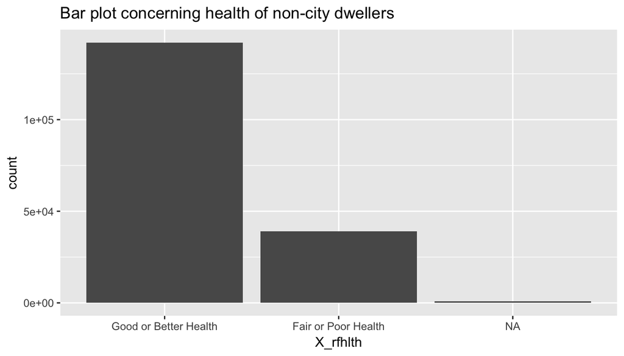

```r
non_city_dweller_data<-brfss2013%>%
  filter(citydweller=="Not a city dweller")
ggplot(non_city_dweller_data, aes(x=X_rfhlth)) +geom_bar() + ggtitle("Bar plot concerning health of non-city dwellers")
```

```r
non_city_total_summary<-non_city_dweller_data[!is.na(non_city_dweller_data$X_rfhlth),]%>% group_by(X_rfhlth) %>%
  summarise(total=n())
non_city_total_summary
```

```
## # A tibble: 2 x 2
##   X_rfhlth               total
##   <fct>                  <int>
## 1 Good or Better Health 141977
## 2 Fair or Poor Health    39015
```

```r
total_non_city_dweller= sum(!is.na(non_city_dweller_data$X_rfhlth))
non_city_dweller_data[!is.na(non_city_dweller_data$X_rfhlth),]%>% group_by(X_rfhlth) %>%
  summarise(proportion=n()/total_non_city_dweller)
```

```
## # A tibble: 2 x 2
##   X_rfhlth              proportion
##   <fct>                      <dbl>
## 1 Good or Better Health      0.784
## 2 Fair or Poor Health        0.216
```

```r
#Storing number of healthy people for non-city dwellers
non_city_success<- as.numeric(non_city_total_summary[1,2])
```

It seems non-city dwellers have a slightly lower proportion of healthy individuals compared to city dwellers i.e 0.784438 (non-city) vs 0.8098015 (city).

Our hypothesis test is as follows: * H0 : The proportions of healthy people for city dwellers and non-city dwellers is the same. * H1 : The proportions of healthy people for city dwellers is greater than non-city dwellers

We use the in-built proprtion test in R:

```r
prop.test(x=c(city_success,non_city_success), n=c(total_city_dweller,total_non_city_dweller), alternative="greater")
```

```
##
##  2-sample test for equality of proportions with continuity
##  correction
##
## data:  c(city_success, non_city_success) out of c(total_city_dweller, total_non_city_dweller)
## X-squared = 350.81, df = 1, p-value < 2.2e-16
## alternative hypothesis: greater
## 95 percent confidence interval:
##  0.02313452 1.00000000
## sample estimates:
##    prop 1    prop 2
## 0.8098015 0.7844380
```

Therefore, the p-value we get is very low. The difference in proportions for healthy people in city vs non-city settings is statistically significant. Therefore, we can safely say city dwellers are slightly more healthier than non-city dwellers which contradicts my initial assumption that non-city dwellers may ne more healthier.

**Research quesion 2:**

These are the following variable we need for our analysis:

- *sex*
- *_rfsmok3*: Current Smoking Calculated Variable
- *_educag*: Computed Level Of Education Completed Categories

Let us remove all the NAs from our dataset to make the analysis easier:

```r
remove_na<-(!is.na(brfss2013$X_educag)&!is.na(brfss2013$X_rfsmok3)&!is.na(brfss2013$sex))
nrow(brfss2013)
```

```
## [1] 491775
```

```r
length(remove_na)
```

```
## [1] 491775
```

```r
brfss_cleaned <- brfss2013[remove_na,]
```

First, we summarise the X_educag variable. Then, we extract a new variable that tells us whether the person is a college graduate or not called *collegegrad*.

```r
brfss_cleaned%>% group_by(X_educag)%>%
  summarise(total=n())
```

```
## # A tibble: 4 x 2
##   X_educag                                    total
##   <fct>                                       <int>
## 1 Did not graduate high school                40556
## 2 Graduated high school                      138120
## 3 Attended college or technical school       130598
## 4 Graduated from college or technical school 165868
```

```r
brfss_cleaned<- brfss_cleaned%>%
  mutate(collegegrad=ifelse(X_educag=="Graduated from college or technical school","Graduate","Non-graduate"))
brfss_cleaned%>% group_by(collegegrad) %>%
  summarise(total=n())
```

```
## # A tibble: 2 x 2
##   collegegrad   total
##   <chr>         <int>
## 1 Graduate     165868
## 2 Non-graduate 309274
```

Now, we create a new categorical variable to make our analysis easier called *sex_collegegrad*. The categories will be as follows:

- Male Graduates
- Female Graduates
- Male Non-graduates
- Female Non-Graduates

```r
#Creating a proportion table
table1<-table(brfss_cleaned$sex, brfss_cleaned$collegegrad)
prop.table(table1)
```

```
##
##           Graduate Non-graduate
##   Male   0.1511296    0.2575756
##   Female 0.1979619    0.3933329
```

```r
brfss_cleaned<- brfss_cleaned %>%
  mutate(sex_collegegrad=paste(sex,collegegrad))
summary_sex_collegegrad<-brfss_cleaned %>% group_by(sex_collegegrad) %>%
  summarise(total=n())%>%
  mutate(proportion = total/sum(total))
summary_sex_collegegrad[order(summary_sex_collegegrad$proportion),]
```

```
## # A tibble: 4 x 3
##   sex_collegegrad      total proportion
##   <chr>                <int>      <dbl>
## 1 Male Graduate        71808      0.151
## 2 Female Graduate      94060      0.198
## 3 Male Non-graduate   122385      0.258
## 4 Female Non-graduate 186889      0.393
```

Now, we try to visualise what are our proportions of smokers vs non-smokers for different categories of *sex_collegegrad*. The weights shall be the number of people in each category of sex_collegegrad

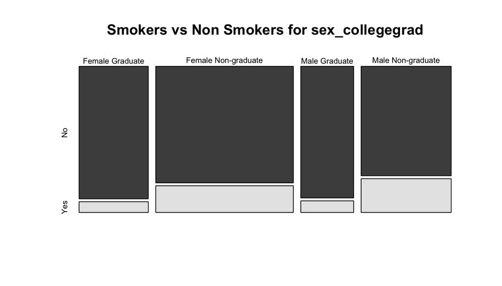

```r
table1<-table(brfss_cleaned$sex_collegegrad,brfss_cleaned$X_rfsmok3)
mosaicplot(table1, main="Smokers vs Non Smokers for sex_collegegrad" ,color=TRUE)
```

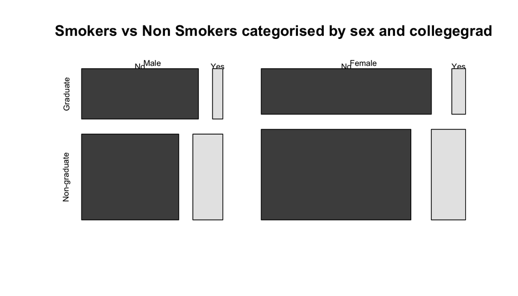

```r
table2<-table(brfss_cleaned$sex, brfss_cleaned$collegegrad, brfss_cleaned$X_rfsmok3)
mosaicplot(table2,main="Smokers vs Non Smokers categorised by sex and collegegrad", color=TRUE)
```

**Research quesion 3:**

For this question, we shall use the following variables: * *sex* * *_imprace *genhlth* * *_rfhlth*

Clean all the NA data. Also, let’s make a test mosaic plot

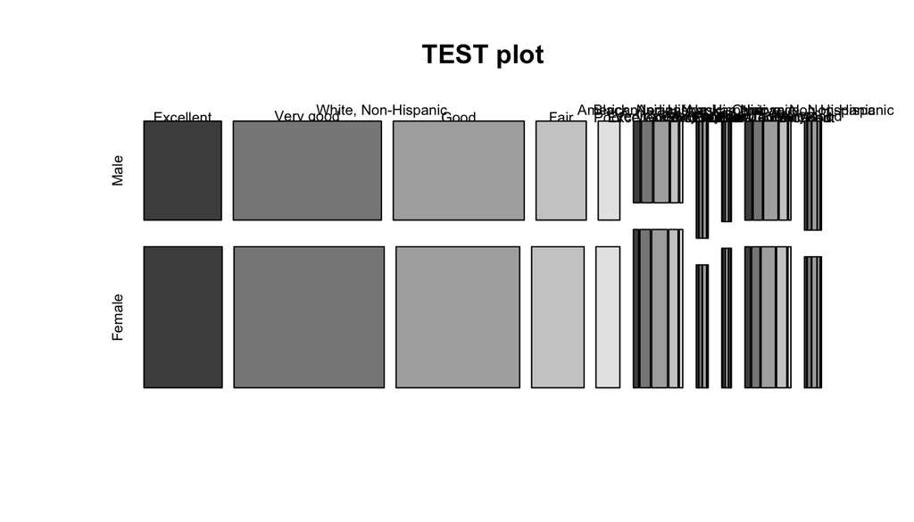

```r
brfss_cleaned_q3 <- brfss2013[!is.na(brfss2013$sex)&!is.na(brfss2013$X_imprace)&!is.na(brfss2013$genhlth),]
table_q3<- table(brfss_cleaned_q3$X_imprace,brfss_cleaned_q3$sex,  brfss_cleaned_q3$genhlth)
mosaicplot(table_q3, main="TEST plot", color = TRUE)
```

The above plot is very cramped and conveys very little information. It would be better to make mosaic plot for each race seperately to get a better insight along with proportions table.

First, Let us separate the data for White, Non-Hispanic:

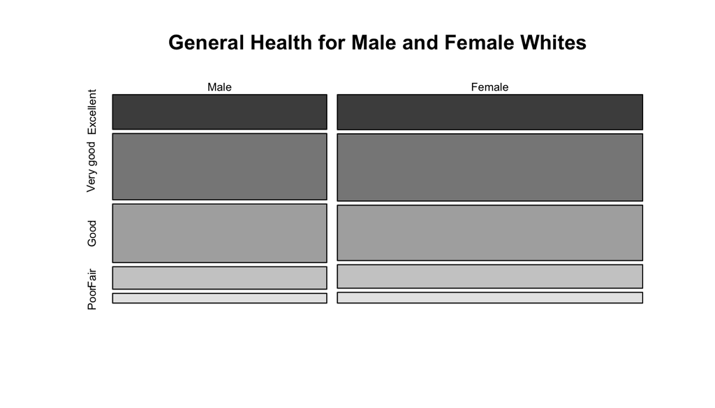

```r
brfss_white<-brfss_cleaned_q3 %>% filter(X_imprace=="White, Non-Hispanic")
table_white<- table(brfss_white$sex,  brfss_white$genhlth)
mosaicplot(table_white, main="General Health for Male and Female Whites", color = TRUE, margin=TRUE)
```

```r
male_white_summary<-brfss_white %>% filter(sex=="Male") %>%
  group_by(genhlth) %>%
  summarise(total=n()) %>%
  mutate(proportion = total/sum(total))
kable(male_white_summary, caption = "Male White Health")
```

Male White Health

| genhlth | total | proportion |
| --- | --- | --- |
| Excellent | 28513 | 0.1809051 |
| Very good | 54486 | 0.3456948 |
| Good | 48173 | 0.3056410 |
| Fair | 18463 | 0.1171414 |
| Poor | 7978 | 0.0506177 |

```r
female_white_summary<-brfss_white %>% filter(sex=="Female") %>%
  group_by(genhlth) %>%
  summarise(total=n()) %>%
  mutate(proportion = total/sum(total))
kable(female_white_summary, caption = "Female White Health")
```

Female White Health

[output not shown]

Now, we investigate for all other races too:

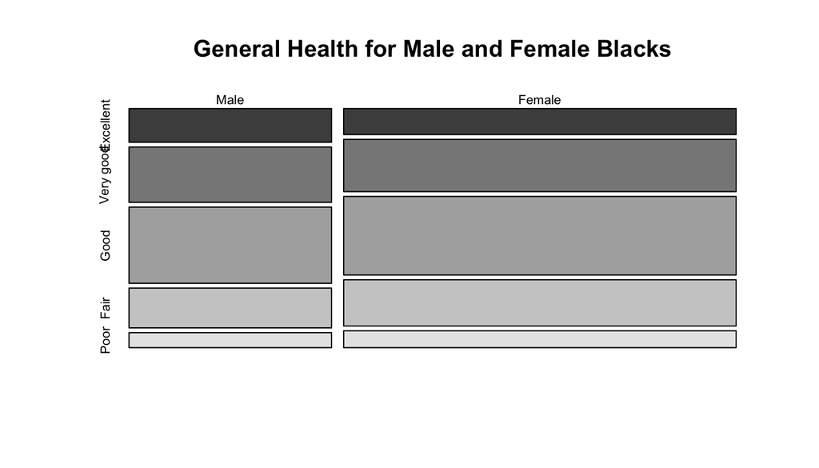

```r
brfss_black<-brfss_cleaned_q3 %>% filter(X_imprace=="Black, Non-Hispanic")
table_black<- table(brfss_black$sex,  brfss_black$genhlth)
mosaicplot(table_black, main="General Health for Male and Female Blacks", color = TRUE, margin=TRUE)
```

```r
male_black_summary<-brfss_black %>% filter(sex=="Male") %>%
  group_by(genhlth) %>%
  summarise(total=n()) %>%
  mutate(proportion = total/sum(total))
kable(male_black_summary, caption = "Male Black Health")
```

Male Black Health

| genhlth | total | proportion |
| --- | --- | --- |
| Excellent | 2064 | 0.1531498 |
| Very good | 3386 | 0.2512429 |
| Good | 4668 | 0.3463679 |
| Fair | 2441 | 0.1811234 |
| Poor | 918 | 0.0681160 |

```r
female_black_summary<-brfss_black %>% filter(sex=="Female") %>%
  group_by(genhlth) %>%
  summarise(total=n()) %>%
  mutate(proportion = total/sum(total))
kable(female_black_summary, caption = "Female Black Health")
```

Female Black Health

| genhlth | total | proportion |
| --- | --- | --- |
| Excellent | 3083 | 0.1180593 |
| Very good | 6214 | 0.2379567 |
| Good | 9330 | 0.3572796 |
| Fair | 5485 | 0.2100406 |
| Poor | 2002 | 0.0766639 |

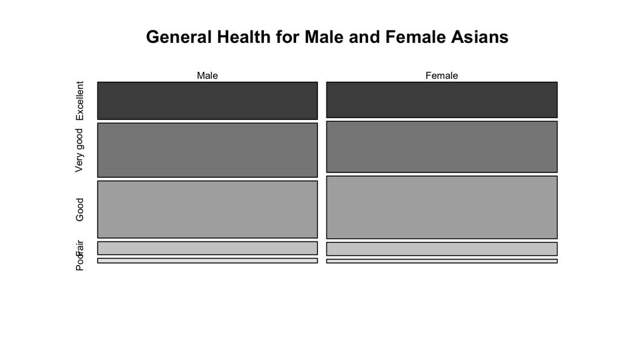

```r
brfss_asian<-brfss_cleaned_q3 %>% filter(X_imprace=="Asian, Non-Hispanic")
table_asian<- table(brfss_asian$sex,  brfss_asian$genhlth)
mosaicplot(table_asian, main="General Health for Male and Female Asians", color = TRUE, margin=TRUE)
```

```r
male_asian_summary<-brfss_asian %>% filter(sex=="Male") %>%
  group_by(genhlth) %>%
  summarise(total=n()) %>%
  mutate(proportion = total/sum(total))
kable(male_asian_summary, caption = "Male Asian Health")
```

Male Asian Health

| genhlth | total | proportion |
| --- | --- | --- |
| Excellent | 1050 | 0.2242631 |
| Very good | 1526 | 0.3259291 |
| Good | 1609 | 0.3436566 |
| Fair | 366 | 0.0781717 |
| Poor | 131 | 0.0279795 |

```r
female_asian_summary<-brfss_asian %>% filter(sex=="Female") %>%
  group_by(genhlth) %>%
  summarise(total=n()) %>%
  mutate(proportion = total/sum(total))
kable(female_asian_summary, caption = "Female Asian Health")
```

Female Asian Health

| genhlth | total | proportion |
| --- | --- | --- |
| Excellent | 1049 | 0.2135586 |
| Very good | 1510 | 0.3074104 |
| Good | 1851 | 0.3768322 |
| Fair | 392 | 0.0798046 |
| Poor | 110 | 0.0223941 |

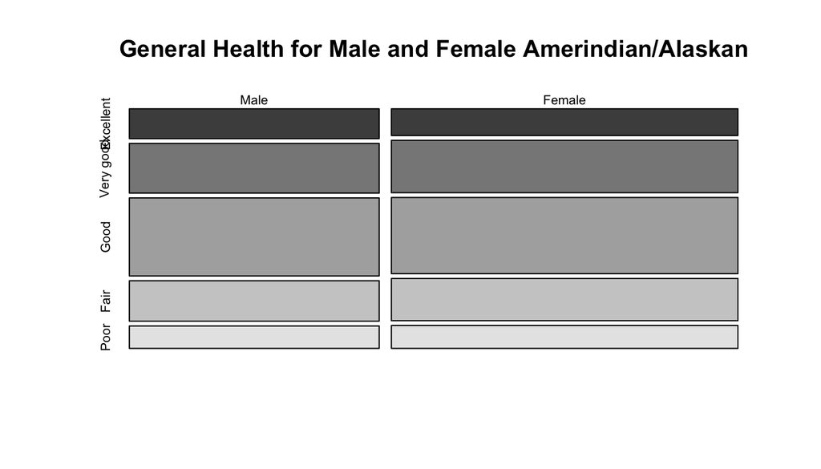

```r
brfss_amerind<-brfss_cleaned_q3 %>% filter(X_imprace=="American Indian/Alaskan Native, Non-Hispanic")
table_amerind<- table(brfss_amerind$sex,  brfss_amerind$genhlth)
mosaicplot(table_amerind, main="General Health for Male and Female Amerindian/Alaskan", color = TRUE, margin=TRUE)
```

```r
male_amerind_summary<-brfss_amerind %>% filter(sex=="Male") %>%
  group_by(genhlth) %>%
  summarise(total=n()) %>%
  mutate(proportion = total/sum(total))
kable(male_amerind_summary, caption = "Male Amerindian/Alaskan Health")
```

Male Amerindian/Alaskan Health

| genhlth | total | proportion |
| --- | --- | --- |
| Excellent | 438 | 0.1350601 |
| Very good | 732 | 0.2257169 |
| Good | 1148 | 0.3539932 |
| Fair | 595 | 0.1834721 |
| Poor | 330 | 0.1017576 |

```r
female_amerind_summary<-brfss_amerind %>% filter(sex=="Female") %>%
  group_by(genhlth) %>%
  summarise(total=n()) %>%
  mutate(proportion = total/sum(total))
kable(female_amerind_summary, caption = "Female Amerindian/Alaskan Health")
```

Female Amerindian/Alaskan Health

| genhlth | total | proportion |
| --- | --- | --- |
| Excellent | 545 | 0.1211650 |
| Very good | 1069 | 0.2376612 |
| Good | 1555 | 0.3457092 |
| Fair | 862 | 0.1916407 |
| Poor | 467 | 0.1038239 |

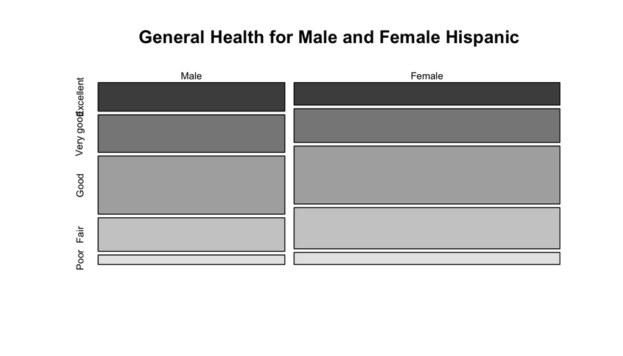

```r
brfss_hisp<-brfss_cleaned_q3 %>% filter(X_imprace=="Hispanic")
table_hisp<- table(brfss_hisp$sex,  brfss_hisp$genhlth)
mosaicplot(table_hisp, main="General Health for Male and Female Hispanic", color = TRUE, margin=TRUE)
```

```r
male_hisp_summary<-brfss_hisp %>% filter(sex=="Male") %>%
  group_by(genhlth) %>%
  summarise(total=n()) %>%
  mutate(proportion = total/sum(total))
kable(male_hisp_summary, caption = "Male Hispanic Health")
```

Male Hispanic Health

| genhlth | total | proportion |
| --- | --- | --- |
| Excellent | 2601 | 0.1708599 |
| Very good | 3414 | 0.2242659 |
| Good | 5293 | 0.3476976 |
| Fair | 3055 | 0.2006832 |
| Poor | 860 | 0.0564935 |

```r
female_hisp_summary<-brfss_hisp %>% filter(sex=="Female") %>%
  group_by(genhlth) %>%
  summarise(total=n()) %>%
  mutate(proportion = total/sum(total))
kable(female_hisp_summary, caption = "Female Hispanic Health")
```

Female Hispanic Health

| genhlth | total | proportion |
| --- | --- | --- |
| Excellent | 2911 | 0.1342960 |
| Very good | 4372 | 0.2016977 |
| Good | 7504 | 0.3461893 |
| Fair | 5334 | 0.2460786 |
| Poor | 1555 | 0.0717383 |

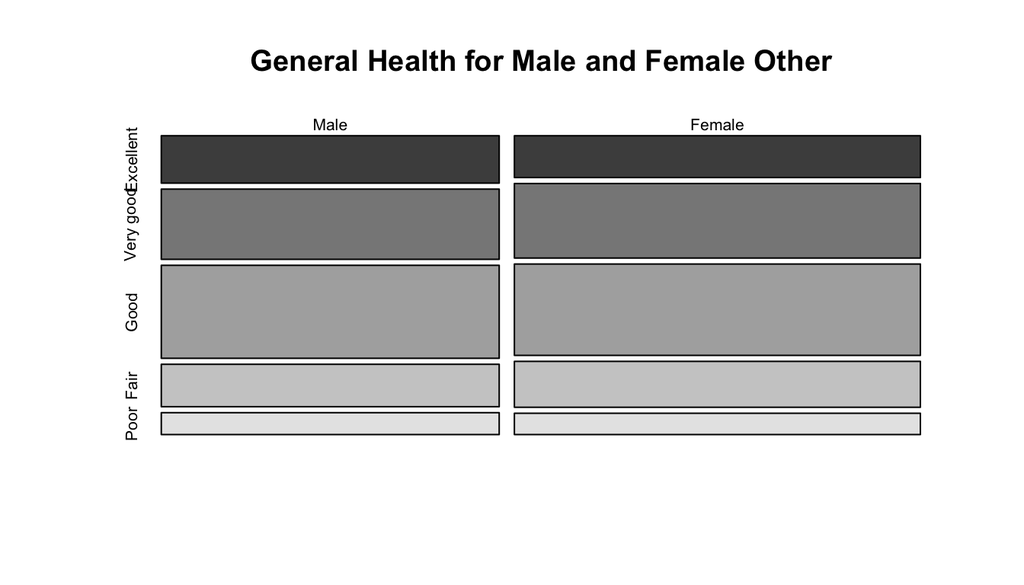

```r
brfss_other<-brfss_cleaned_q3 %>% filter(X_imprace=="Other race, Non-Hispanic")
table_other<- table(brfss_other$sex,  brfss_other$genhlth)
mosaicplot(table_other, main="General Health for Male and Female Other", color = TRUE, margin=TRUE)
```

```r
male_other_summary<-brfss_other %>% filter(sex=="Male") %>%
  group_by(genhlth) %>%
  summarise(total=n()) %>%
  mutate(proportion = total/sum(total))
kable(male_other_summary, caption = "Male Other Health")
```

Male Other Health

| genhlth | total | proportion |
| --- | --- | --- |
| Excellent | 1074 | 0.1724193 |
| Very good | 1591 | 0.2554182 |
| Good | 2107 | 0.3382565 |
| Fair | 961 | 0.1542784 |
| Poor | 496 | 0.0796275 |

```r
female_other_summary<-brfss_other %>% filter(sex=="Female") %>%
  group_by(genhlth) %>%
  summarise(total=n()) %>%
  mutate(proportion = total/sum(total))
kable(female_other_summary, caption = "Female Other Health")
```

Female Other Health

| genhlth | total | proportion |
| --- | --- | --- |
| Excellent | 1138 | 0.1520577 |
| Very good | 2029 | 0.2711117 |
| Good | 2487 | 0.3323089 |
| Fair | 1250 | 0.1670230 |
| Poor | 580 | 0.0774987 |

Now, we have got a brief idea for all of the races. Let us summarise this by using a contingency table showing proportions for each category:

```r
x<-ftable(X_rfhlth~X_imprace+sex, data = brfss_cleaned_q3 )
prop.table(x,margin=1)
```

```
##                                                     X_rfhlth Good or Better Health Fair or Poor Health
## X_imprace                                    sex
## White, Non-Hispanic                          Male                        0.8322410           0.1677590
##                                              Female                      0.8217307           0.1782693
## Black, Non-Hispanic                          Male                        0.7507606           0.2492394
##                                              Female                      0.7132956           0.2867044
## Asian, Non-Hispanic                          Male                        0.8938488           0.1061512
##                                              Female                      0.8978013           0.1021987
## American Indian/Alaskan Native, Non-Hispanic Male                        0.7147703           0.2852297
##                                              Female                      0.7045353           0.2954647
## Hispanic                                     Male                        0.7428065           0.2571935
##                                              Female                      0.6821831           0.3178169
## Other race, Non-Hispanic                     Male                        0.7660941           0.2339059
##                                              Female                      0.7554784           0.2445216
```

From the contingency table, we are able to observe that Asian Females are amongst the most healthy (89.7%) and the least healthy are Hispanic Females (68.2%). Whites are after Asians in health.